# Reproducible Research: Peer Assessment 1

## Loading and preprocessing the data

```r
# Loading  required libraries
library(dplyr)
library(lubridate)
library(ggplot2)
library(downloader)
library(scales)
```

```r
# Creating required project structure
wd_saved = getwd()

project_name = "RepData_PeerAssessment1"
project_dir = file.path(getwd(), project_name)

if (!file.exists(project_name)){
    dir.create(project_dir)
}

setwd(project_dir)

if (!file.exists("data")){
    dir.create("data")
}
```

```r
# Downloading and processing initial data
download("https://d396qusza40orc.cloudfront.net/repdata%2Fdata%2Factivity.zip",
         "data/activity.zip", mode = "wb")
unzip("data/activity.zip", exdir = "data")
```

```r
steps_data <- read.table("./data/activity.csv", header = TRUE,
                       sep = ",", stringsAsFactors = FALSE)
steps_tbl <- tbl_df(steps_data)
steps_tbl <- mutate(steps_tbl, date = ymd(date))
```

## What is mean total number of steps taken per day?

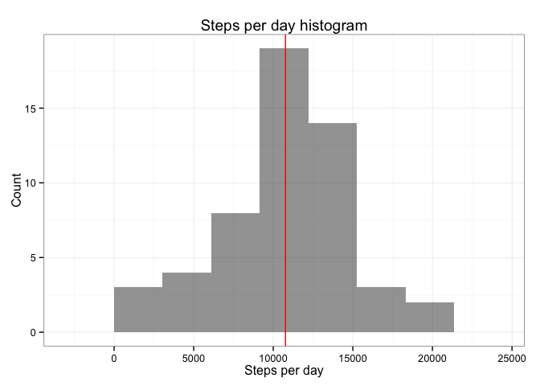

```r
steps_per_day <- steps_tbl %>% group_by(date) %>% summarise(sum_steps = sum(steps))

n <- length(steps_per_day$sum_steps)
r <- diff(range(steps_per_day$sum_steps, na.rm = TRUE))
steps_hist <- ggplot(steps_per_day, aes(sum_steps))
steps_hist + geom_histogram(binwidth = r / (log2(n)+1), alpha = .5) +
    theme_bw() +
    labs(title = "Steps per day histogram", x = "Steps per day", y = "Count") +
    geom_vline(xintercept = mean(steps_per_day$sum_steps, na.rm = TRUE), color = "red")
```

Mean total number of steps taken per day can be found from the summary output:

```r
summary(steps_per_day$sum_steps, digits = 7)
```

```
##     Min.  1st Qu.   Median     Mean  3rd Qu.     Max.     NA's
##    41.00  8841.00 10765.00 10766.19 13294.00 21194.00        8
```

```r
mean(steps_per_day$sum_steps, na.rm = TRUE)
```

```
## [1] 10766.19
```

```r
median(steps_per_day$sum_steps, na.rm = TRUE)
```

```
## [1] 10765
```

## What is the average daily activity pattern?

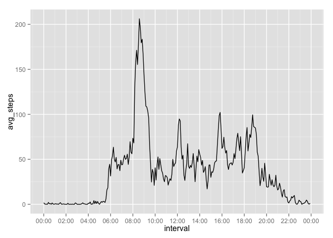

```r
activity_pattern <- steps_tbl %>% group_by(interval) %>% summarise(avg_steps = mean(steps, na.rm = TRUE))

activity_pattern <- mutate(activity_pattern, interval = parse_date_time(sprintf("%04d", interval), "%H%M"))

ggplot(activity_pattern, aes(interval, avg_steps)) +
    geom_line() +
    scale_x_datetime(breaks = "120 min", labels = date_format("%H:%M"))
```

5-minute interval that, on average across all the days in the dataset, contains the maximum number of steps:

```r
activity_pattern %>% filter(avg_steps == max(avg_steps))
```

```
## Source: local data frame [1 x 2]
##
##              interval avg_steps
## 1 0000-01-01 08:35:00  206.1698
```

## Imputing missing values

Total number and percentage of missing values in our data set:

```r
sum(is.na(steps_tbl$steps))
```

```
## [1] 2304
```

```r
mean(is.na(steps_tbl$steps))
```

```
## [1] 0.1311475
```

Lets fill the NA positions with corrsponding values from activity_pattern:

```r
na_length = length(steps_tbl[is.na(steps_tbl$steps), ]$steps)

steps_tbl2 <- steps_tbl

steps_tbl2[is.na(steps_tbl2$steps), ]$steps <- rep(activity_pattern$avg_steps, length.out = na_length)
```

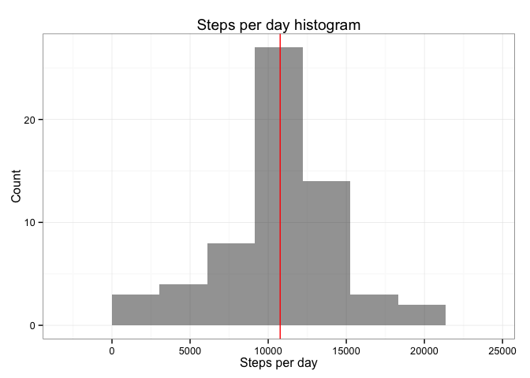

```r
steps_per_day2<- steps_tbl2 %>% group_by(date) %>% summarise(sum_steps = sum(steps))

n <- length(steps_per_day$sum_steps)
r <- diff(range(steps_per_day2$sum_steps))
steps_hist <- ggplot(steps_per_day2, aes(sum_steps))
steps_hist + geom_histogram(binwidth = r / (log2(n)+1), alpha = .5) +
    theme_bw() +
    labs(title = "Steps per day histogram", x = "Steps per day", y = "Count") +
    geom_vline(xintercept = mean(steps_per_day2$sum_steps), color = "red")
```

New mean total number of steps taken per day can be found from the summary output:

```r
summary(steps_per_day2$sum_steps, digits = 7)
```

```
##     Min.  1st Qu.   Median     Mean  3rd Qu.     Max.
##    41.00  9819.00 10766.19 10766.19 12811.00 21194.00
```

```r
mean(steps_per_day2$sum_steps)
```

```
## [1] 10766.19
```

```r
median(steps_per_day2$sum_steps)
```

```
## [1] 10766.19
```

As we can see, imputing missing values hasn’t changed mean and median significantly.

## Are there differences in activity patterns between weekdays and weekends?

Lets create a new factor variable in the dataset with two levels – “weekday” and “weekend” indicating whether a given date is a weekday or weekend day.

```r
steps_per_weekdays <- mutate(steps_tbl2, wd = factor(weekdays(date) %in% c("Sunday", "Saturday")))
levels(steps_per_weekdays$wd) <- c("weekday", "weekend")
wd_act_pattern <- mutate(steps_per_weekdays, interval = parse_date_time(sprintf("%04d", interval), "%H%M"))
wd_act_pattern <- wd_act_pattern %>% group_by(interval, wd) %>% summarise(avg_steps = mean(steps))
```

Now we can make a panel plot containing a time series plot of the 5-minute interval (x-axis) and the average number of steps taken, averaged across all weekday days or weekend days (y-axis)

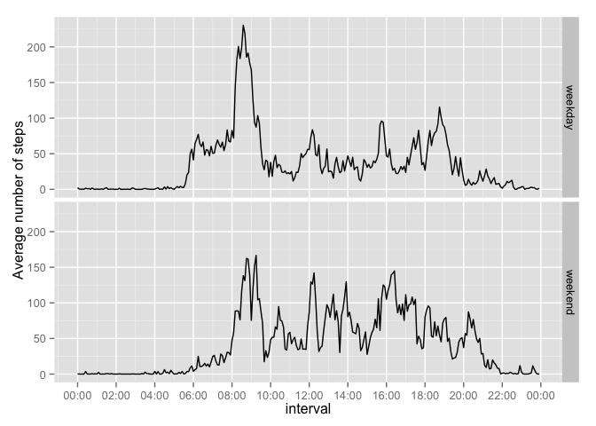

```r
ggplot(wd_act_pattern, aes(interval, avg_steps)) +
    geom_line() +
    scale_x_datetime(breaks = "120 min", labels = date_format("%H:%M")) +
    facet_grid(wd ~ .) +
    ylab("Average number of steps")
```

So we can see that the activity patterns between weekdays and weekends are quite different. During weeekdays our subject’s active phase starts earlier (around 6:00) and has a glaring peek around 9:00. Meanwhile, during weekends subject’s active phase starts later (around 8:00) and has a lot of medium peaks

```r
setwd(wd_saved)
```